# C05

Previous: Lecture 4 Decision Making , next: Lecture 6 For Loop

Lecture 5 Array and String

#### CSCI218 Engineering Programming (by Kebin Xu)

1. Array
   - Array declaration
   - Array Initialization and examples
   - Array indexing, assignment and elements updating
2. C string
   - string defination
   - C string library functions
   - C Char library functions:ctype
     - Character checking functions
     - Character checking functions in Arduino C
     - Character conversion functions
   - Arduino C String datatype
3. Iterate through string

1. Array

A typical variable stores one data item, like the number 59 or the character 'a'. Instead, sometimes a list of data items should be stored.

- Ex: A program recording points scored in each quarter of a basketball game needs a list of 4 numbers. Requiring a programmer to declare 4 variables is annoying; 200 variables would be ridiculous.
- An **array** is a collection of data of the `same type` (and therefore, the same size) stored in consecutive memory cells under `one name`.
- An entire array is declared all at once.
- Each individual element in the array can be referenced by `indexing`.
  - Indexed means the array elements are numbered and always start at 0.
  - indexing an element of an array by specifying the array name followed by one or more subscripts, with each subscript enclosed in square brackets.

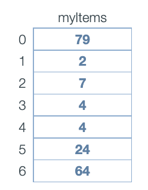

1.1 Declaring an Array

The general form is :

```
typeName arrayName[length];
```

- This declares an array with the specified `length`, named `arrayName` and with type `typeName`.
- The array is indexed from 0 to (**length-1**).
- The length (in brackets) must be an integer literal or a constant variable.
- The compiler uses the length to determine how much space to allocate (i.e. how many bytes).
- Here are some examples :

```c
//Example 5-1.1
#include <stdio.h>
int main( ) {
    // An array named myItems is declared, 7 elements, each element of data type int
    int myItems[7]; // index is 0, 1, 2, 3, 4, 5, 6
    char name[20];  // An array of 20 characters,
    float nums[10]; // An array of 10 floating numbers; nums[0], nums[1], …,nums[9]
    int table[5][10]; // A two dimensional array of integers
    //float grade[]; //ERROR, you have to specify length of the array

    const int ROLL_NUMBERS = 16;
    int classStudents[ROLL_NUMBERS]; //it works for some compiler


    myItems[3] = 4; //initialize assignment
    myItems[0] = 79;
    myItems[6] = 64;

    printf("myItems[0]= %d\n",myItems[0] );

    myItems[0] = 50; //updating
    printf("myItems[0]= %d",myItems[0] );

    name[0] = 'k';
    //nums[10] = 4.5; //Why this cause ERROR?
    //name[1] = 3.5;//wrong

  return 0;
}
```

```
myItems[0]= 79
myItems[0]= 50
```

back to top

Array Initialization

## 1.2.1 initialize using index

initialize the array one by one after declaration by accessing the element using index

```c
//Example 5-1.2.1
#include <stdio.h>
int main(){

    float numbers[3]; // declare a float of array of length 3, so the index is 0, 1, 2
    numbers[0] = 13.25;
    numbers[1] = 12.09;
    numbers[2] = 8.1;
    return 0;
}
```

## 1.2.2 initialize using {}

initialize the array using {} The general form is :

```
typeName arrayName[< length is optional>] = { list of values }; // length has to be larger than or equal to the actural number of values
```

you can use built-in function **sizeof()** ot get the `size` of an array (the datatype is unsigned long) , which is `number of elements * size of datatype`

size of an array = length of array * size of the data type

length of array= size of array / size of the data type

```c
//Example 5.1.2_A size of different data type
#include <stdio.h>
int main(){
    printf("The size of an int is: %lu\n", sizeof(int));
    printf("The size of a long is: %lu\n", sizeof(long));
    printf("The size of a short is: %lu\n", sizeof(short));
    printf("The size of a char is: %lu\n", sizeof(char));
    printf("The size of a float is: %lu\n", sizeof(float));
    printf("The size of a double is: %lu\n", sizeof(double));

}
```

```
The size of an int is: 4
The size of a long is: 8
The size of a short is: 2
The size of a char is: 1
The size of a float is: 4
The size of a double is: 8
```

```c
//Example 5.1.2_B
#include <stdio.h>
int main(){
    //int num[6] = {1, 3, 5, 7, 9, 11}; // equivalent to  int num[] = {1, 3, 5, 7, 9, 11};
    // ERROR: int num[5] = {1, 3, 5, 7, 9, 11};
    char letters[] = {'a', 'b', 'c', 'd', 'e'};
    printf("%c \n",letters[4] );

    int A[] = {2, 4, 6, 8}; // A is an integer array of 4 elements
    float numbers[3] = {13.25, 12.09, 8.1};
    int length = sizeof(letters)/sizeof(char); // get the length of array letters
    printf("length of array letters is %d\n", length);
    printf("length of A is %lu\n", sizeof(A)/sizeof(int));//using size of data type
    printf("length of A is %lu\n", sizeof(A)/sizeof(A[0]));//using size of one element
    printf("length of numbers is %lu\n", sizeof(numbers)/sizeof(float));

    return 0;

}
```

```
e
length of array letters is 5
length of A is 4
length of A is 4
length of numbers is 3
```

back to top

1.3 Array indexing, assignment and elements updating

A key advantage of arrays becomes evident when used in conjunction with `loops`. Arrays combined with `loops` are powerful together

```c
//Examples 5-1.3A using for loop to display the elements of array
#include <stdio.h>
int main(){
    int num[10] = {1, 3, 5, 7, 9, 11};
    char letters[] = {'a', 'b', 'c', 'd', 'e'};
    float numbers[] = {13.25, 12.09, 8.1};

    int i; // loop index
    int numSize = sizeof(num)/sizeof(int);

    printf("num[2]= %d\n", num[2]);
    num[2] = 20; //updating
    printf("num[2]= %d\n\n", num[2]);

    num[9]= 90;
    for (i = 0;i < numSize;i++){
        printf("num[%d] = %d\n",i, num[i]);
    }
    printf("\n");
    for(i = 0; i< sizeof(letters)/sizeof(char) ; i++){
        printf("letters[%d] = %c\n", i, letters[i]);
    }

    numbers[0] = 15.7;
    for (i = 0;i < sizeof(numbers)/sizeof(numbers[0]);i++){
        printf("numbers[%d] = %.2f\n",i, numbers[i]);
    }

    return 0;
}
```

```
num[2]= 5
num[2]= 20

num[0] = 1
num[1] = 3
num[2] = 20
num[3] = 7
num[4] = 9
num[5] = 11
num[6] = 0
num[7] = 0
num[8] = 0
num[9] = 90

letters[0] = a
letters[1] = b
letters[2] = c
letters[3] = d
letters[4] = e
numbers[0] = 15.70
numbers[1] = 12.09
numbers[2] = 8.10
```

```c
//Example 5-1.3B
// ask for user to enter all elements of an array one by one
#include <stdio.h>
int main() {

    float hws[5];
    int i, numHWs;
    printf("Enter how many homeworks (<= 5):");
    scanf("%d", &numHWs);

    for (i = 0; i< numHWs, i++){
        printf("Enter your homework %d:", i + 1);
        scanf("%f", &hws[i]);
    }

    for (i = 0; i< numHWs; i++)
        printf("%.1f ", hws[i]);

  return 0;
}
```

**Example**: write C code to store 10 even numbers starting from 0 to an integer array *nums*

- e.g. 0, 2, 4, 6, 8, 10, 12, 14, 16, 18

```c
//Example 5-1.3C
#include <stdio.h>
int main(){
    int nums[10]; // declare an array of 10 integers
    int i; // loop index

    for (i = 0; i < sizeof(nums)/sizeof(int); i++){
        //printf("%d\t", i * 2); // generate 10 even numbers
        nums[i] = i * 2;
        printf("%d\t", nums[i]);
    }
    return 0;
}
```

```
0	2	4	6	8	10	12	14	16	18
```

**Example** using for loop to copy the elements of array A to array B

```c
//Example 5-1.3Da
//Is the following code good enough?
#include <stdio.h>
int main(){
    int A[] = {2, 4, 6, 8}; // A is an integer array of length 4
    int B[3];
    int i; // loop index
    for (i = 0; i<sizeof(B)/sizeof(int) ; i++)
    {
        B[i]= A[i];
        printf("B[%d] = %d\n",i,  B[i]);
    }
    return 0;
}
```

```
B[0] = 2
B[1] = 4
B[2] = 6
```

```c
//Example 5-1.3Db using for loop to copy the elements of array A to array B
#include <stdio.h>
int main(){
    int A[] = {2, 4, 6, 8}; // A is an integer array of length 4
    int B[7];
    int i; // loop index
    printf("\nCopy A to B\n");

    //copy the elements of A to B : this require A and B has the same length
    // or the copied array has smaller length
    if(sizeof(B)/sizeof(int) <= sizeof(A)/sizeof(int)){
        for (i = 0; i< sizeof(B)/sizeof(int); i++){
            B[i] = A[i];
            printf("B[%d] = %d \n",i, B[i]);
        }
    }
    else printf("Lenght of A is less than the length of B ");
    return 0;
}
```

[output not shown]

back to top

## 2 C strings

A string is a sequence of ASCII characters treated as a **single entity**.

### 2.1 define the string as a character **array**.

```
- An array is a grouping of one or more elements of a data type
- an array __string__ has to be end with '\0', which is called null character
- Example : char ch1[5]={'J', 'a', 'n', 'e', '\0'};
- array index starts from 0
```

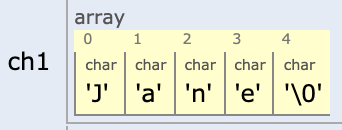

While declaring string, length is not mandatory. So we can write the above code as given below:

```
char ch2[] = {'J', 'a', 'n', 'e', '\0'};
```

or

### 2.2 define the string by the string literal in C language

```
char ch3[] = "Jane";
```

- complier will figure out that 5 bytes of storage for hold letter 'J','a','n','e' and '\0'
- In such case, '\0' will be appended at the end of the string by the compiler.
- An array of charcters ending with a '\0' is known as a **null-terminated string**
- printf() will display all characters up to '\0' for a string
- **sizeof()** is used to calculate the **size** (in bytes)that a data type/ or an array occupies in the computer's memory. (use %lu )
- **strlen(`str`)** is used to compute the **length** of the string `str` up to, but not including the terminating null character.(use %ld )

```c
#include <stdio.h>
#include <string.h> //for strlen()

int main(){
    int grade[5] = {68, 78, 99, 100};
    printf("size of grade is : %lu\n ", sizeof(grade));
    printf("length of grade is %lu\n", sizeof(grade)/sizeof(int));

    char ch1[7] = {'J', 'a', 'n', 'e', '\0'}; //the length must be large enough to include the '\0'
    char ch2[] = {'J', 'a', 'n', 'e', '\0'};
    //char ch2[]; //ERROR!! you have to specify the length if you don't initialize the array when you declare it
    char ch3[] = "Jane"; //complier will figure out that 5 bytes of storage to hold letter 'J','a','n','e' and '\0'
    char ch4[5] = "Jane"; // good for hold exact 4 characters
    //char ch4[4] = "Jane";   // ERROR!  There is not enough storage to hold '\0'
    char ch5[20] = "Jane"; // ch5 can hold at most 19 characters, waste storage
    printf("ch1 = %s, ch2 = %s, ch3 = %s, ch5 = %s, ch4= %s \n",ch1, ch2, ch3, ch5, ch4);

    // the return of strlen() is a long  integer, so the placeholder is  %ld
    printf("The length of ch1 is %ld, ch2 is %ld,  ch3 is %ld, ch4 is %ld, ch5 is %ld\n", strlen(ch1), strlen(ch2),strlen(ch3),strlen(ch4),strlen(ch5));
    // the return of sizeof() is a long unsigned integer, so the placeholder is %lu
    printf("the size of ch1 is %lu, ch2 is %lu, ch3 is %lu, ch4 is %lu, ch5 is %lu\n ", sizeof(ch1),sizeof(ch2),sizeof(ch3),sizeof(ch4), sizeof(ch5));

    return 0;
}
```

[output not shown]

```c
#include <stdio.h>
#include <string.h> //for strlen()

int main(){
    char myText[11] = {'C', 'S', 'C', 'I', ' ', '2', '1', '8', '\0'};
    printf("size of myText: %lu\n",sizeof(myText));
    printf("length of myText: %ld\n",strlen(myText));
    return 0;
}
```

```
size of myText: 11
length of myText: 8
```

### NOTE:

**C string is not assignable after declared**

```c
#include <stdio.h>
#include <string.h> //for strlen(), strcpy()

int main(){

    char ch1[7];
    //ch1 = "Jane"; //ERROR, C string is not assignable

    ch1[0] = 'J';
    ch1[1] = 'a';
    ch1[2] = 'n';
    ch1[3] = 'e';
    printf("%s\n", ch1); // might print "Jane",
                        //if ch1[4] is initialized as 0 by default by the compiler
                        // the ASCII code of '\0' happens to be 0
                        //OR print hundreds, or thousands, of values untill it meets '\0' in the memory

    ch1[4] = '\0';    //Good practice
    printf("Good practice: %s\n", ch1);

    strcpy(ch1, "Jane");
    printf("%s", ch1);
    return 0;
}
```

[output not shown]

back to top

### 2.3 C string library functions

- C provides common dunctions for working with C strings, presented in the **string.h** library. more [refer to](https://www.javatpoint.com/c-string-functions)
- Given

  ```
  char orgNmae[100] = "United Nations";
    char userText[20] = "UNICEF";
    char targetText[10];
  ```

[figure not shown]

```c
#include<stdio.h>
#include <string.h>
int main(){
    char str1[5] = "Hi!!!";
    char str2[] = "Bye";
    strcpy(str1, str2);
    printf("%s", str1);

    return 0;
}
```

```
Bye
```

```c
#include<stdio.h>
#include <string.h>
int main(){
    char ch[20]="Jane";
    printf("Length of %s is %lu\n", ch,strlen(ch));

    printf("\nstrcpy(des,src):sizeof(des) should >= strlen(src)....\n");
    char ch2[5];    //char ch2[]; will cause error
    strcpy(ch2,ch); //will cause error if size of destination is smaller than the strlength of source
    printf("Copy of %s is %s\n",ch, ch2);

    printf("\nstrcat(fst,snd):sizeof(fst) should >= strlen(fst) + strlen(snd)...\n");
    char ch3[10]={'y', '\0'};
    strcat(ch,ch3);
    printf("%s concats %s is %s, length is %lu, size if %ld\n",ch, ch3, ch, strlen(ch), sizeof(ch));

    printf("\nstrcmp(str1,str2): return 0 if str1 are equal to str2...\n");
    char ch4[] = {'J','a','n','e','y','\0'};
    if(strcmp(ch,ch4)==0)
      printf("1. %s and %s are equal\n", ch, ch4);
    else
      printf("1. %s and %s are not equal\n", ch, ch4);
    char ch5[] = {'J','a','n','e','y'};
    if(strcmp(ch,ch5)==0)
      printf("2. %s and %s are equal\n", ch, ch5);
    else
      printf("2. %s and %s are not equal\n", ch, ch5);
    char ch6[] = "Janey";
    if(strcmp(ch,ch6)==0)
      printf("3. %s and %s are equal\n", ch, ch6);
    else
       printf("3. %s and %s are not equal\n", ch, ch6);


    //printf("\nReverse string is: %s",strrev(ch)); // does not work in most compiler????
    //printf("\nLower String is: %s",strlwr(ch4));   //no strlwr and strupr
 return 0;
}
```

```
Length of Jane is 4

strcpy(des,src):sizeof(des) should >= strlen(src)....
Copy of Jane is Jane

strcat(fst,snd):sizeof(fst) should >= strlen(fst) + strlen(snd)...
Janey concats y is Janey, length is 5, size if 20

strcmp(str1,str2): return 0 if str1 are equal to str2...
1. Janey and Janey are equal
2. Janey and JaneyJaney are not equal
3. Janey and Janey are equal
```

```c
//Concatenate two strings
#include <stdio.h>
#include <string.h>
#include <ctype.h>
int main()
{
    char str1[20] = "Hello!9 ";
    char str2[] = "CSCI218";
    strcat(str1, str2); //str1 should have enough space to hold all characters of two strings + '\0'
    printf("%s", str1);

    return 0;

}
```

```
Hello!9 CSCI218
```

**Q** can you concatenate a letter to a string?

```c
#include <stdio.h>
#include <string.h>

int main() {
    char str[20] = "Good";
    char letter ='A';
    char letterStr[2] = "A";

    //strcat(str,'A'); //Error
    //strcat(str,letter); //Error
    //strcat(str,"A"); //OKay
    strcat(str,letterStr);
    printf("%s",str);
    return 0;
}
```

```
GoodA
```

back to top

### 2.4 C Char library functions:ctype

C provides common functions for working with characters, presented in the **ctype.h**. More [refer to](http://www.cplusplus.com/reference/cctype/)

#### 2.4.1 Character checking functions

the following functions check whether a character is of a given category, returning either false(0) or true(non-zero)

```
char myString[30] = "Hey9! Go";
```

[figure not shown]

back to top

#### 2.4.2 Character checking functions in Arduino C 【CSCI218Lab】

Please refer to the [Arduino reference](https://www.arduino.cc/reference/en/) for the floowing characters checking functions

- [isAlpha()](https://www.arduino.cc/reference/en/language/functions/characters/isalpha/)
- [isAlphaNumeric()](https://www.arduino.cc/reference/en/language/functions/characters/isalphanumeric/)
- [isAscii()](https://www.arduino.cc/reference/en/language/functions/characters/isascii/)
- [isDigit()](https://www.arduino.cc/reference/en/language/functions/characters/isdigit/)
- [isHexadecimalDigit()](https://www.arduino.cc/reference/en/language/functions/characters/ishexadecimaldigit/): Analyse if a char is an hexadecimal digit (A-F, 0-9)
- [isLowerCase()](https://www.arduino.cc/reference/en/language/functions/characters/islowercase/)
- [isUpperCase()](https://www.arduino.cc/reference/en/language/functions/characters/isuppercase/)
- [isSpace()](https://www.arduino.cc/reference/en/language/functions/characters/isspace/)
- [isWhitespace()](https://www.arduino.cc/reference/en/language/functions/characters/iswhitespace/)
- [isControl()](https://www.arduino.cc/reference/en/language/functions/characters/iscontrol/)
- [isPunct()](https://www.arduino.cc/reference/en/language/functions/characters/ispunct/)
- [isPrintable()](https://www.arduino.cc/reference/en/language/functions/characters/isprintable/)
- [isGraph()](https://www.arduino.cc/reference/en/language/functions/characters/isgraph/): Analyse if a char is printable with some content (space is printable but has no content). Returns true if thisChar is printable. isGraph() tests for the same characters as isPrint(), but the space character is not included.

Refer to [examples](https://www.tutorialspoint.com/arduino/arduino_character_functions.htm) to understand the usage of those functions

back to top

#### 2.4.3 Character conversion functions

Functions that convert a character is of a given category

```
char letter;
```

[figure not shown]

back to top

### 2.5 Arduino C String datatype 【CSCI218Lab】

```
String my_string = "JANE" ;
```

- They are immutable. Once they are defined, they can’t be changed.
- It refers to a sequence of characters, which is represented as a `single` data type **String**.
- It contains built-in functions such as substring(), charAt().
  - The charAt() method helps access characters at a specific index within a ‘String’.
- The **‘+’** operator can be used to append strings together, which would form a new string.
- A string can be converted to a character array using toCharArray() method of ‘String’ class.

Character Arrays vs Strings

- Character Arrays are mutable which means their values can be changed.
- It is a sequential collection of data type ‘char’. The values in a character array are stored in contiguous memory locations.
- The characters in a character array can be accessed using index.

back to top

## 3. Iterate through string

### Example

**E1.1_Q1** convert all lowecase letter of a string to all uppcase letter

```c
//E1.1_Q1a: use strlen()
#include <stdio.h>
#include <ctype.h>
#include <string.h> //for strlen()
int main() {
    char str1[] = "Hello";
    char uppercase;
    int i;
    for (i = 0; i<strlen(str1); i++){

        uppercase = toupper(str1[i]);
        str1[i] = uppercase;
    }
    printf("%s", str1);
    return 0;
}
```

```
HELLO
```

```c
//E1.1_Q1b: use str1[i]!= '\0'
#include <stdio.h>
#include <ctype.h>

int main() {
    char str1[] = "Hello!9";
    char uppercase;
    int i;
    for (i = 0; str1[i]!= '\0'; i++){
        str1[i] = toupper(str1[i]);
    }
    printf("%s", str1);
    return 0;
}
```

```
HELLO!9
```

**Q** can you concatenate a letter to a string?

```c
#include <stdio.h>
#include <string.h>

int main() {
    char str[20] = "Good";
    char letter ='A';
    char letterStr[2];
    letterStr[0] = letter;
    letterStr[1] = '\0';

    //strcat(str,'A'); //Error
    //strcat(str,"A"); //OKay
    strcat(str,letterStr);
    printf("%s",str);
    return 0;
}
```

```
GoodA
```